# Pre-Processing the Varieties of Democracy Dataset

## Country Code Checks

The most important issue to address with country-year datasets is accurate annual country codes. This includes nation-state secessions and independence (Sudan, Yugoslavia), independently listed territories (Hong Kong, Puerto Rico, Guam, French Guiana), and states with limited international recognition (Kosovo, West Bank/Palestine, Taiwan). These issues afflict international datasets in a wide variety of ways. Before you attempt to “fix” these issues, it’s important to consider how they will be addressed in all the datasets required for your analysis. Do not spend copious amounts of time coding changes to Kosovo and the West Bank if they’re completely ignored in your other datasets of concern.

V-Dem contains Correlates of War (CoW; `COWcode`) country codes. This is a popular coding scheme that makes country-coding an easier task. We’ll start be renaming the variable, because we will have to manipulate it a lot.

```r
names(vdem)[2]<-"cow"
```

The *states* package can serve as a reference to check Correlates of War and Gleditsch and Ward country codes. Both are embedded in the package and available with calls to `states::cowstates` or `states::gwstates`. Let’s start by checking if any CoW codes are missing.

```r
unique(vdem[is.na(cow),country_name])
```

```
#> [1] "Palestine/West Bank" "Palestine/Gaza"      "Somaliland"
#> [4] "Hong Kong"           "Zanzibar"
```

It may seem like the easy way out, but these states are commonly ignored in popular environment-security datasets, and can usually be dropped from analysis. One dataset where they would be included is United Nations refugee and asylum seeker data, in which case, you would have to introduce ISO codes to harmonize them with other United Nations data. This could be done with minimal trouble using the *countrycode* package, but will likely lead to other issues.

```r
library(countrycode)

vdem[, iso3:=countrycode::countrycode(cow,
                                      origin = "cown",
                                      destination = "iso3c")]
```

```r
vdem[cow %in% c(260, 265, 315, 345, 347, 511, 678, 680, 817), unique(country_name)]
```

```
#> [1] "Yemen"                      "South Yemen"
#> [3] "Republic of Vietnam"        "Kosovo"
#> [5] "Germany"                    "German Democratic Republic"
#> [7] "Czechia"                    "Serbia"
#> [9] "Zanzibar"
```

These require hard-coded fixes to their ISO3 values. This is beyond the scope of the purpose of this vignette so we will drop the missing `cow` observations in V-Dem and move on, but I wanted to illustrate the beginning of a country code black hole.

```r
vdem <- vdem[!is.na(cow)][, iso3:=NULL]
```

### Yugoslavia, Serbia, Montenegro, and Kosovo

Official CoW codes for Yugoslavia, Serbia, Montenegro, and Kosovo are 345, 345, 341, and 347, respectively. CoW maintains the 345 numeric AND YUG character designations for Serbia after the Yugoslavia break. CoW assigns Montenegro 341 starting in 2006 and Kosovo 347 in 2008 (review these changes in `states::cowstates`).

Check how V-Dem assigns these changes.

```r
dcast(vdem[cow %in% c(345, 341, 347), .(country_name, cow, year)],
      year~cow, value.var = "country_name")
```

```
#>     year        341    345    347
#>  1: 1951       <NA> Serbia   <NA>
#>  2: 1952       <NA> Serbia   <NA>
#>  3: 1953       <NA> Serbia   <NA>
#>  4: 1954       <NA> Serbia   <NA>
#>  5: 1955       <NA> Serbia   <NA>
#>  6: 1956       <NA> Serbia   <NA>
#>  7: 1957       <NA> Serbia   <NA>
#>  8: 1958       <NA> Serbia   <NA>
#>  9: 1959       <NA> Serbia   <NA>
#> 10: 1960       <NA> Serbia   <NA>
#> 11: 1961       <NA> Serbia   <NA>
#> 12: 1962       <NA> Serbia   <NA>
#> 13: 1963       <NA> Serbia   <NA>
#> 14: 1964       <NA> Serbia   <NA>
```

[output cut: 59 more lines]

```r
for(i in 1995:2005) vdem[cow %in% c(341,345) & year==i, (metrics):=lapply(.SD, mean, na.rm = TRUE), .SDcols = metrics]
```

The coverage and coding for Kosovo is correct; it can be left if other data of interest recognizes the state.

### Other Considerations

Sudan (625) and South Sudan (626) split in 2011. Check them in V-Dem.

```r
dcast(vdem[cow %in% c(625,626), .(country_name, cow, year)],year~cow, value.var = "country_name")
```

```
#>     year   625         626
#>  1: 1951 Sudan        <NA>
#>  2: 1952 Sudan        <NA>
#>  3: 1953 Sudan        <NA>
#>  4: 1954 Sudan        <NA>
#>  5: 1955 Sudan        <NA>
#>  6: 1956 Sudan        <NA>
#>  7: 1957 Sudan        <NA>
#>  8: 1958 Sudan        <NA>
#>  9: 1959 Sudan        <NA>
#> 10: 1960 Sudan        <NA>
#> 11: 1961 Sudan        <NA>
#> 12: 1962 Sudan        <NA>
#> 13: 1963 Sudan        <NA>
#> 14: 1964 Sudan        <NA>
```

[output cut: 59 more lines]

This is correct. Lastly, we should check V-Dem against our CoW reference (`states::cowstates`) to see if V-Dem is missing any countries.

```r
cowstates<-data.table::setDT(states::cowstates)
missing_in_vdem<-cowstates[end >= sprintf("%s-01-01", 1995)][!cowcode %in% vdem$cow]
knitr::kable(missing_in_vdem)
```

| cowcode | cowc | country_name | start | end | microstate |
| --- | --- | --- | --- | --- | --- |
| 31 | BHM | Bahamas | 1973-07-10 | 9999-12-31 | FALSE |
| 54 | DMA | Dominica | 1978-11-03 | 9999-12-31 | TRUE |
| 55 | GRN | Grenada | 1974-02-07 | 9999-12-31 | TRUE |
| 56 | SLU | St. Lucia | 1979-02-22 | 9999-12-31 | TRUE |
| 57 | SVG | St. Vincent and the Grenadines | 1979-10-27 | 9999-12-31 | TRUE |
| 58 | AAB | Antigua & Barbuda | 1981-11-01 | 9999-12-31 | TRUE |
| 60 | SKN | St. Kitts and Nevis | 1983-09-19 | 9999-12-31 | TRUE |
| 80 | BLZ | Belize | 1981-09-21 | 9999-12-31 | FALSE |
| 221 | MNC | Monaco | 1993-05-28 | 9999-12-31 | TRUE |
| 223 | LIE | Liechtenstein | 1990-09-18 | 9999-12-31 | TRUE |
| 232 | AND | Andorra | 1993-07-28 | 9999-12-31 | TRUE |
| 331 | SNM | San Marino | 1992-03-02 | 9999-12-31 | TRUE |
| 835 | BRU | Brunei | 1984-01-01 | 9999-12-31 | FALSE |
| 946 | KIR | Kiribati | 1999-09-14 | 9999-12-31 | TRUE |
| 947 | TUV | Tuvalu | 2000-09-05 | 9999-12-31 | TRUE |
| 955 | TON | Tonga | 1999-09-14 | 9999-12-31 | TRUE |
| 970 | NAU | Nauru | 1999-09-14 | 9999-12-31 | TRUE |
| 983 | MSI | Marshall Islands | 1991-09-17 | 9999-12-31 | TRUE |
| 986 | PAL | Palau | 1994-12-15 | 9999-12-31 | TRUE |
| 987 | FSM | Federated States of Micronesia | 1991-09-17 | 9999-12-31 | TRUE |
| 990 | WSM | Samoa | 1976-12-15 | 9999-12-31 | TRUE |

There is nothing of consequence here; these are mostly microstates that are commonly omitted from environment-security analysis. For simplicity, the remaining microstates included in V-Dem may be dropped unless you are carrying out a specialized analysis.

```r
microstates <- cowstates[microstate==TRUE,unique(cowcode)]
vdem<-vdem[!(cow %in% microstates)]
```

Finally, we’ll examine V-Dem for duplicate country names to ensure we don’t miss any peculiarities.

```r
dupes<-unique(vdem[,.(country_name, cow)])
# check for duplicate names across codes
table(duplicated(dupes$country_name))
```

```
#>
#> FALSE  TRUE
#>   175     3
```

## Missing Values

As previously covered, `v2x_polyarchy` and `v2x_libdem` are 2 high level (`vartype==D`) democracy indices quantifying the extent of electoral and liberal democracy in a given state. Both metrics are continuous variables bound by 0-1. We can quickly check their distributions to get a better sense of the data.

```
#> Warning: Removed 107 rows containing non-finite values (`stat_bin()`).
```

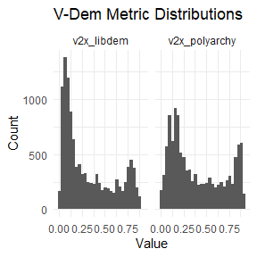

```r
hist.dat<-melt(vdem,
               id.vars = c("cow", "year"),
               measure.vars = c("v2x_libdem",
                                "v2x_polyarchy"),
               variable.name = "metric",
               value.name = "value")

ggplot2::ggplot(hist.dat, ggplot2::aes(x=value))+
  ggplot2::geom_histogram()+
  ggplot2::facet_wrap(~metric)+
  ggplot2::labs(title = "V-Dem Metric Distributions",
                x = "Value",
                y= "Count")+
  ggplot2::theme_minimal()
```

These look pretty good with (mostly) uniform converage. The warnings have tipped us off to a few missing values; let’s investigate further.

```r
vdem[is.na(v2x_libdem) | is.na(v2x_polyarchy),.(unique(country_name), n=.N, last_year=max(year)), by=cow]
```

```
#>    cow                       V1  n last_year
#> 1: 475                  Nigeria  1      1959
#> 2: 482 Central African Republic  2      1965
#> 3: 860              Timor-Leste 48      1998
#> 4: 705               Kazakhstan  1      1990
#> 5: 565                  Namibia  1      1979
#> 6: 701             Turkmenistan  1      1990
#> 7: 692                  Bahrain 51      2001
```

```r
vdem[cow==860, .(country_name, year, v2x_libdem, v2x_polyarchy)]
```

```
#>     country_name year v2x_libdem v2x_polyarchy
#>  1:  Timor-Leste 1951         NA         0.017
#>  2:  Timor-Leste 1952         NA         0.017
#>  3:  Timor-Leste 1953         NA         0.017
#>  4:  Timor-Leste 1954         NA         0.017
#>  5:  Timor-Leste 1955         NA         0.017
#>  6:  Timor-Leste 1956         NA         0.017
#>  7:  Timor-Leste 1957         NA         0.017
#>  8:  Timor-Leste 1958         NA         0.017
#>  9:  Timor-Leste 1959         NA         0.017
#> 10:  Timor-Leste 1960         NA         0.018
#> 11:  Timor-Leste 1961         NA         0.018
#> 12:  Timor-Leste 1962         NA         0.018
#> 13:  Timor-Leste 1963         NA         0.018
#> 14:  Timor-Leste 1964         NA         0.018
```

[output cut: 59 more lines]

Now Bahrain.

```r
vdem[cow==692, .(country_name, year, v2x_libdem, v2x_polyarchy)]
```

```
#>     country_name year v2x_libdem v2x_polyarchy
#>  1:      Bahrain 1951         NA         0.023
#>  2:      Bahrain 1952         NA         0.023
#>  3:      Bahrain 1953         NA         0.025
#>  4:      Bahrain 1954         NA         0.025
#>  5:      Bahrain 1955         NA         0.025
#>  6:      Bahrain 1956         NA         0.025
#>  7:      Bahrain 1957         NA         0.025
#>  8:      Bahrain 1958         NA         0.025
#>  9:      Bahrain 1959         NA         0.025
#> 10:      Bahrain 1960         NA         0.023
#> 11:      Bahrain 1961         NA         0.024
#> 12:      Bahrain 1962         NA         0.024
#> 13:      Bahrain 1963         NA         0.024
#> 14:      Bahrain 1964         NA         0.024
```

[output cut: 59 more lines]

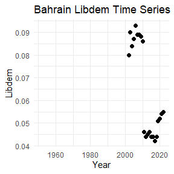

```r
ggplot2::ggplot(vdem[cow==692], ggplot2::aes(x=year, y=v2x_libdem))+
  ggplot2::geom_point(size = 2)+
  ggplot2::labs(title="Bahrain Libdem Time Series",
                x = "Year",
                y = "Libdem")+
  ggplot2::theme_minimal()
```

```r
vdem[cow==692 & year==2001, v2x_libdem := vdem[cow==692 & year==2002, v2x_libdem]]
```

## Final Cleanup

Before finishing, we will perform a few final processing steps. First, extract only the minimum number of variables.

```r
vdem <- vdem[, .(cow, year, v2x_libdem, v2x_polyarchy)]
```

Next, set the year and CoW columns to integers.

```r
cols<-c("cow", "year")
vdem[, (cols):=lapply(.SD, as.integer), .SDcols = cols]
```

Lastly, if you are working with other colleagues, strip the *data.table* class from the object.

```r
data.table::setDF(vdem)
```

And we’re finished. I hope you found this exercise informative, and please contact me with any questions, concerns, or tips.

# References

Coppedge, Michael, John Gerring, Carl Henrik Knutsen, Staffan I. Lindberg, Jan Teorell, David Altman, Michael Bernhard, et al. 2020. “V-Dem Codebook V10.” SSRN Scholarly Paper ID 3557877. Rochester, NY: Social Science Research Network. https://doi.org/10.2139/ssrn.3557877.

Freedom House. 2014. *Freedom in the World 2014: The Annual Survey of Political Rights and Civil Liberties*. Rowman & Littlefield. https://books.google.com?id=uiDfBQAAQBAJ.

Marshall, Monty, and Keith Jaggers. 2002. “Polity IV Project: Political Regime Characteristics and Transitions, 1800-2002.”

Pemstein, Daniel, Kyle L. Marquardt, Eitan Tzelgov, Yi-ting Wang, Joshua Krusell, and Farhad Miri. 2018. “The V-Dem Measurement Model: Latent Variable Analysis for Cross-National and Cross-Temporal Expert-Coded Data.” SSRN Scholarly Paper ID 3167764. Rochester, NY: Social Science Research Network. https://doi.org/10.2139/ssrn.3167764.

The World Bank. 2017. “World Development Indicators.” Data Set. Washington, DC: The World Bank. https://datacatalog.worldbank.org/dataset/world-development-indicators.

Wig, Tore, Håvard Hegre, and Patrick M. Regan. 2015. “Updated Data on Institutions and Elections 1960–2012: Presenting the IAEP Dataset Version 2.0.” *Research & Politics* 2 (2): 2053168015579120. https://doi.org/10.1177/2053168015579120.